# Dimensionality reduction techniques

## Principal Component Analysis

### Overview of the data

I am going to use the method of Principal Component Analysis (PCA) on a data set, I have constructed from Human Development Index data and Gender Inequality Index data. The purpose of this exercise is to reduce the dimensions of the resulting data set, in other words, “compress” the varibles into a smaller number of components, that we could then attempt to interpret.

This data set consists of 155 countries and 8 variables. The summary of the variables suggest, that global development is imbalanced (shoker!). For instance, we can see drastic differences between means ans medians in maternal mortality ratio (`Mat.Mor`) and adolescent birth rate (`Ado.Birth`), that suggests that there is a group of countries with very high values, pushing the mean up. Correlation plot suggests that there is a significant positive relationship between these valuables. Furthemore, the two variables have strong negative relationships with life expectancy (`Life.Exp`), education expectancy (`Edu.Exp`) and the ratio of female and male secondary education expectancy (`Edu2.FM`).

Also can be of interest a dramatic rise from min to 1st quantile in `Edu2.FM`, and the ration of participation in the labor market (`Labo.FM`).

```r
library(tidyr)
library(dplyr)
```

```r
library(ggplot2)
library(GGally)
library(corrplot)
# reading the data

human <- read.table("http://s3.amazonaws.com/assets.datacamp.com/production/course_2218/datasets/human2.txt", sep = ",", header = TRUE)

str(human)
```

```
## 'data.frame':    155 obs. of  8 variables:
##  $ Edu2.FM  : num  1.007 0.997 0.983 0.989 0.969 ...
##  $ Labo.FM  : num  0.891 0.819 0.825 0.884 0.829 ...
##  $ Edu.Exp  : num  17.5 20.2 15.8 18.7 17.9 16.5 18.6 16.5 15.9 19.2 ...
##  $ Life.Exp : num  81.6 82.4 83 80.2 81.6 80.9 80.9 79.1 82 81.8 ...
##  $ GNI      : int  64992 42261 56431 44025 45435 43919 39568 52947 42155 32689 ...
##  $ Mat.Mor  : int  4 6 6 5 6 7 9 28 11 8 ...
##  $ Ado.Birth: num  7.8 12.1 1.9 5.1 6.2 3.8 8.2 31 14.5 25.3 ...
##  $ Parli.F  : num  39.6 30.5 28.5 38 36.9 36.9 19.9 19.4 28.2 31.4 ...
```

```r
# summaries of variables
summary(human)
```

```
##     Edu2.FM          Labo.FM          Edu.Exp         Life.Exp
##  Min.   :0.1717   Min.   :0.1857   Min.   : 5.40   Min.   :49.00
##  1st Qu.:0.7264   1st Qu.:0.5984   1st Qu.:11.25   1st Qu.:66.30
##  Median :0.9375   Median :0.7535   Median :13.50   Median :74.20
##  Mean   :0.8529   Mean   :0.7074   Mean   :13.18   Mean   :71.65
##  3rd Qu.:0.9968   3rd Qu.:0.8535   3rd Qu.:15.20   3rd Qu.:77.25
##  Max.   :1.4967   Max.   :1.0380   Max.   :20.20   Max.   :83.50
##       GNI            Mat.Mor         Ado.Birth         Parli.F
##  Min.   :   581   Min.   :   1.0   Min.   :  0.60   Min.   : 0.00
##  1st Qu.:  4198   1st Qu.:  11.5   1st Qu.: 12.65   1st Qu.:12.40
##  Median : 12040   Median :  49.0   Median : 33.60   Median :19.30
##  Mean   : 17628   Mean   : 149.1   Mean   : 47.16   Mean   :20.91
##  3rd Qu.: 24512   3rd Qu.: 190.0   3rd Qu.: 71.95   3rd Qu.:27.95
##  Max.   :123124   Max.   :1100.0   Max.   :204.80   Max.   :57.50
```

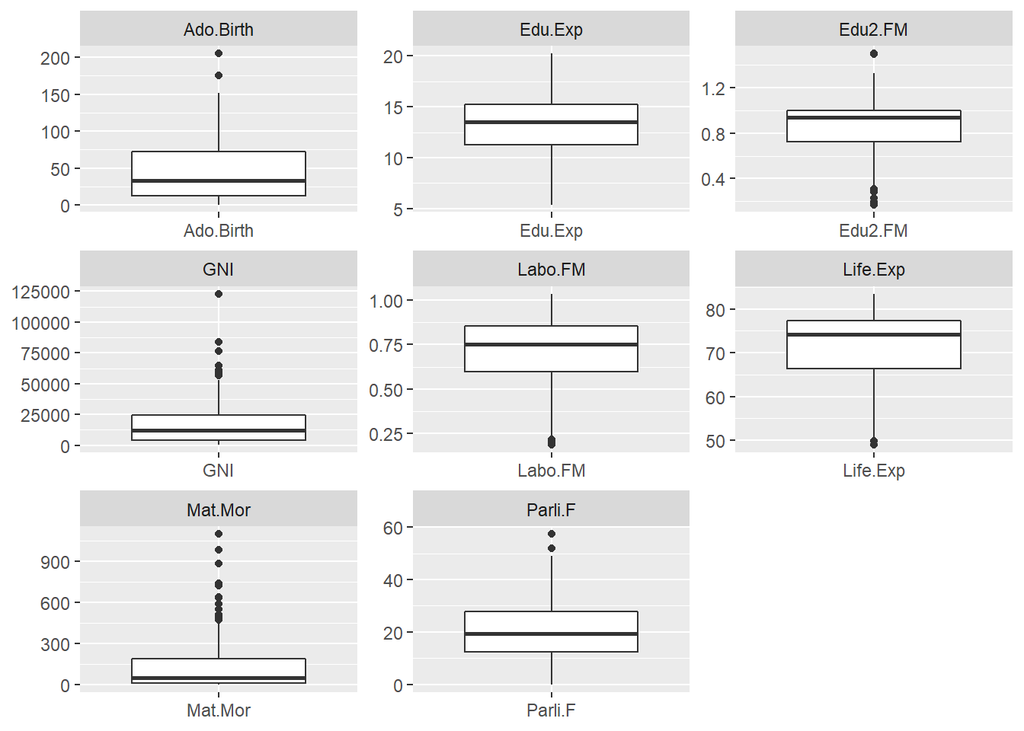

```r
# visual summary
gather(human) %>% ggplot(aes(x = key,y = value)) + facet_wrap("key", scales = "free") + geom_boxplot() + labs(x = NULL, y = NULL)
```

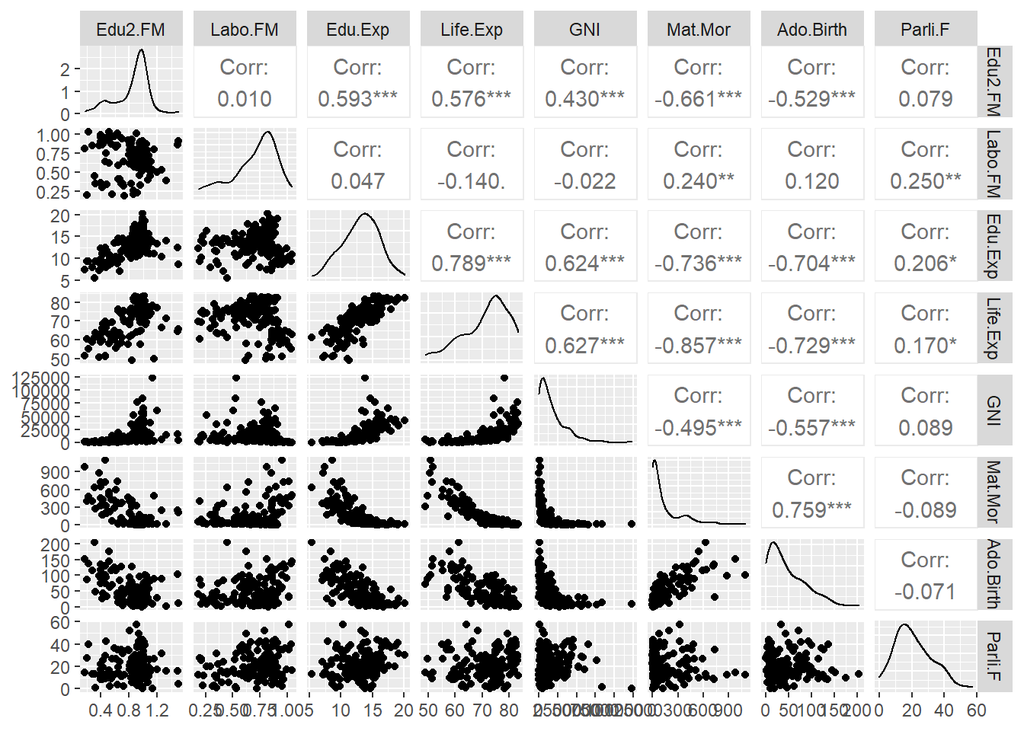

```r
# correlation plots
ggpairs(human)
```

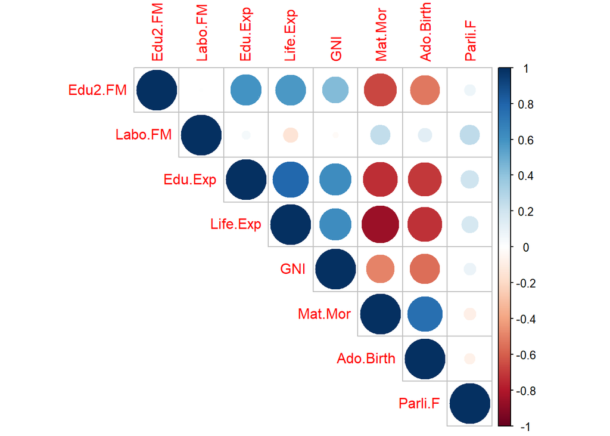

```r
cor(human) %>% corrplot(type = "upper")
```

### PCA on not-standardized data set

```r
# display variance
human %>% summarise_all(var)
```

```
##     Edu2.FM    Labo.FM  Edu.Exp Life.Exp       GNI  Mat.Mor Ado.Birth  Parli.F
## 1 0.0583897 0.03951293 8.067024 69.42328 343874462 44854.83  1690.201 131.9683
```

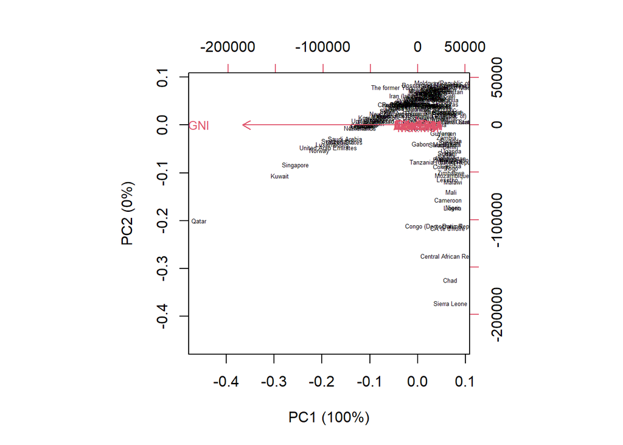

```r
# running pca
pca_human <- prcomp(human)

# calculating percentages of variance
s <- summary(pca_human)
pca_pr <- round(100*s$importance[2, ], digits = 1)

# drawing a biplot
## creating labels
pc_lab <- paste0(names(pca_pr), " (", pca_pr, "%)")

## biplot
biplot(pca_human, choices = 1:2, cex = c(0.4, 0.8), xlab = pc_lab[1], ylab = pc_lab[2])
```

### PCA on standardized data set

```r
# scaling the data set
human_std <- scale(human) %>% as.data.frame()

# scaled variance
human_std %>% summarise_all(var)
```

```
##   Edu2.FM Labo.FM Edu.Exp Life.Exp GNI Mat.Mor Ado.Birth Parli.F
## 1       1       1       1        1   1       1         1       1
```

```r
# running pca
pca_human_std <- prcomp(human_std)
pca_human_std
```

```
## Standard deviations (1, .., p=8):
## [1] 2.0708380 1.1397204 0.8750485 0.7788630 0.6619563 0.5363061 0.4589994
## [8] 0.3222406
##
## Rotation (n x k) = (8 x 8):
##                   PC1         PC2         PC3         PC4        PC5
## Edu2.FM   -0.35664370  0.03796058 -0.24223089  0.62678110 -0.5983585
## Labo.FM    0.05457785  0.72432726 -0.58428770  0.06199424  0.2625067
## Edu.Exp   -0.42766720  0.13940571 -0.07340270 -0.07020294  0.1659678
## Life.Exp  -0.44372240 -0.02530473  0.10991305 -0.05834819  0.1628935
## GNI       -0.35048295  0.05060876 -0.20168779 -0.72727675 -0.4950306
## Mat.Mor    0.43697098  0.14508727 -0.12522539 -0.25170614 -0.1800657
## Ado.Birth  0.41126010  0.07708468  0.01968243  0.04986763 -0.4672068
## Parli.F   -0.08438558  0.65136866  0.72506309  0.01396293 -0.1523699
##                   PC6         PC7         PC8
## Edu2.FM    0.17713316  0.05773644  0.16459453
## Labo.FM   -0.03500707 -0.22729927 -0.07304568
## Edu.Exp   -0.38606919  0.77962966 -0.05415984
## Life.Exp  -0.42242796 -0.43406432  0.62737008
## GNI        0.11120305 -0.13711838 -0.16961173
## Mat.Mor    0.17370039  0.35380306  0.72193946
## Ado.Birth -0.76056557 -0.06897064 -0.14335186
## Parli.F    0.13749772  0.00568387 -0.02306476
```

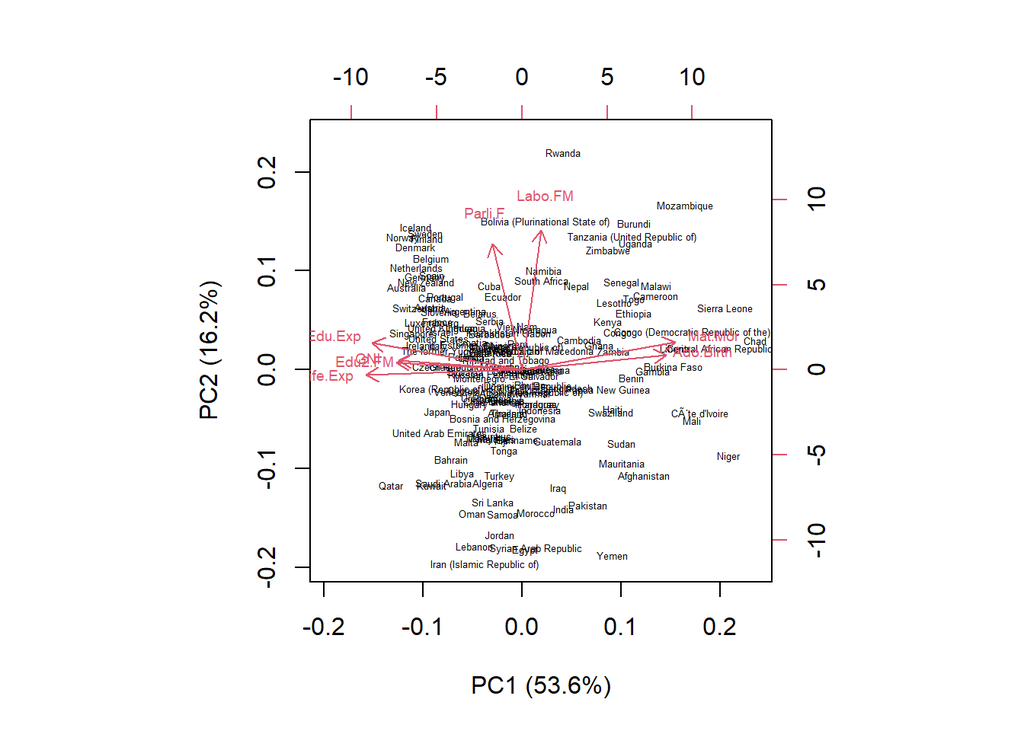

```r
# calculating percentages of variance
s2 <- summary(pca_human_std)
pcapr <- round(100*s2$importance[2, ], digits = 1)

# drawing a biplot
## creating labels
pc_lab2 <- paste0(names(pcapr), " (", pcapr, "%)")


## biplot
biplot(pca_human_std, choices = 1:2, cex = c(0.4, 0.6), xlab = pc_lab2[1], ylab = pc_lab2[2])
```

### Interpretation

PCA on not-standardized data shows that GNI as a variable with the highest variance is enough to predict the overall variance of the data set.

When the data set is scaled, the variance of each variable is 1, and we can see that principal components has become more multifaceted. The second biplot demonstrates that:

- PC1 of a country is pulled to positive values by adolescent birth rate and maternal mortality ratio. It is pulled to negative values by GNI, life expectancy at birth, expectancy of education and secondary education ratio between women and men.
- PC2 of a country is pulled to positive values by women’s labour force participation rate and proportion of women in parliament.

Overall, PC1 could be regarded as women’s quality of life index, PC2 - as women’s societal integration index.

## Multipal Correspondence Analysis

### Data

Multiple Correspondence Analysis (MCA) is a technique that can help to understand proximities between categorical variables by plotting them against two dimensions, we construct in a way similar to PCA. For this exersice I am using tea data set from the packsge FactoMineR, that records various attributes of tea consumtion. It consists of 300 observations over 36 varianles. Below is the summary and the graphic overvie of this data.

```r
# reading the data
library(FactoMineR)
data("tea")

# overview
str(tea)
```

```
## 'data.frame':    300 obs. of  36 variables:
##  $ breakfast       : Factor w/ 2 levels "breakfast","Not.breakfast": 1 1 2 2 1 2 1 2 1 1 ...
##  $ tea.time        : Factor w/ 2 levels "Not.tea time",..: 1 1 2 1 1 1 2 2 2 1 ...
##  $ evening         : Factor w/ 2 levels "evening","Not.evening": 2 2 1 2 1 2 2 1 2 1 ...
##  $ lunch           : Factor w/ 2 levels "lunch","Not.lunch": 2 2 2 2 2 2 2 2 2 2 ...
##  $ dinner          : Factor w/ 2 levels "dinner","Not.dinner": 2 2 1 1 2 1 2 2 2 2 ...
##  $ always          : Factor w/ 2 levels "always","Not.always": 2 2 2 2 1 2 2 2 2 2 ...
##  $ home            : Factor w/ 2 levels "home","Not.home": 1 1 1 1 1 1 1 1 1 1 ...
##  $ work            : Factor w/ 2 levels "Not.work","work": 1 1 2 1 1 1 1 1 1 1 ...
##  $ tearoom         : Factor w/ 2 levels "Not.tearoom",..: 1 1 1 1 1 1 1 1 1 2 ...
##  $ friends         : Factor w/ 2 levels "friends","Not.friends": 2 2 1 2 2 2 1 2 2 2 ...
##  $ resto           : Factor w/ 2 levels "Not.resto","resto": 1 1 2 1 1 1 1 1 1 1 ...
##  $ pub             : Factor w/ 2 levels "Not.pub","pub": 1 1 1 1 1 1 1 1 1 1 ...
##  $ Tea             : Factor w/ 3 levels "black","Earl Grey",..: 1 1 2 2 2 2 2 1 2 1 ...
##  $ How             : Factor w/ 4 levels "alone","lemon",..: 1 3 1 1 1 1 1 3 3 1 ...
```

[output cut: 22 more lines]

```r
summary(tea)
```

```
##          breakfast           tea.time          evening          lunch
##  breakfast    :144   Not.tea time:131   evening    :103   lunch    : 44
##  Not.breakfast:156   tea time    :169   Not.evening:197   Not.lunch:256
##
##
##
##
##
##         dinner           always          home           work
##  dinner    : 21   always    :103   home    :291   Not.work:213
##  Not.dinner:279   Not.always:197   Not.home:  9   work    : 87
##
##
##
##
##
##         tearoom           friends          resto          pub
##  Not.tearoom:242   friends    :196   Not.resto:221   Not.pub:237
##  tearoom    : 58   Not.friends:104   resto    : 79   pub    : 63
##
##
##
##
##
##         Tea         How           sugar                     how
##  black    : 74   alone:195   No.sugar:155   tea bag           :170
##  Earl Grey:193   lemon: 33   sugar   :145   tea bag+unpackaged: 94
##  green    : 33   milk : 63                  unpackaged        : 36
##                  other:  9
##
##
##
##                   where                 price          age        sex
##  chain store         :192   p_branded      : 95   Min.   :15.00   F:178
##  chain store+tea shop: 78   p_cheap        :  7   1st Qu.:23.00   M:122
##  tea shop            : 30   p_private label: 21   Median :32.00
##                             p_unknown      : 12   Mean   :37.05
##                             p_upscale      : 53   3rd Qu.:48.00
##                             p_variable     :112   Max.   :90.00
##
```

[output cut: 25 more lines]

```
##  feminine    :129   Not.sophisticated: 85   No.slimming:255   exciting   :116
##  Not.feminine:171   sophisticated    :215   slimming   : 45   No.exciting:184
##
##
##
##
##
##         relaxing              effect.on.health
##  No.relaxing:113   effect on health   : 66
##  relaxing   :187   No.effect on health:234
##
##
##
##
##
```

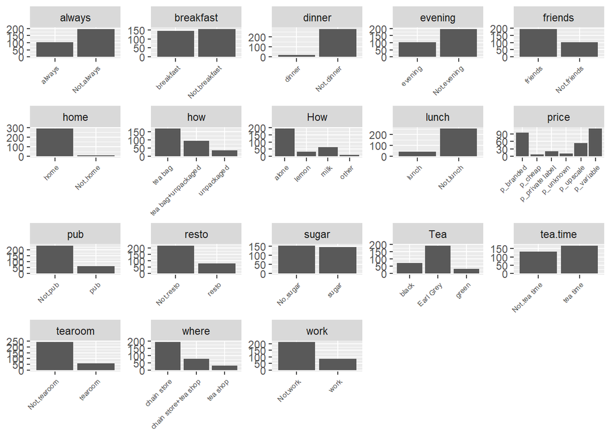

```r
gather(tea[1:18]) %>% ggplot(aes(value)) + facet_wrap("key", scales = "free") + geom_bar() + theme(axis.text.x = element_text(angle = 45, hjust = 1, size = 6))+ labs(x = NULL, y = NULL)
```

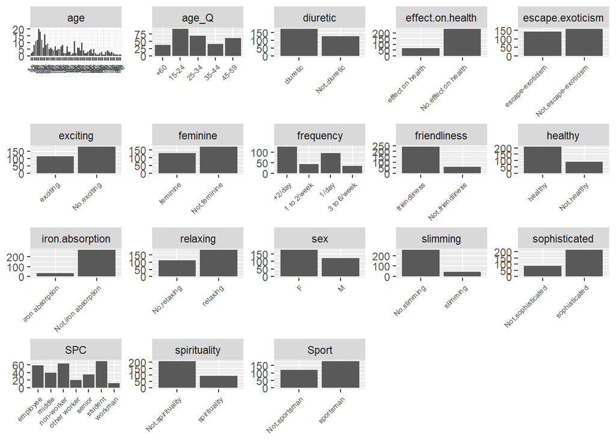

```r
gather(tea[19:36]) %>% ggplot(aes(value)) + facet_wrap("key", scales = "free") + geom_bar() + theme(axis.text.x = element_text(angle = 45, hjust = 1, size = 6))+ labs(x = NULL, y = NULL)
```

### MCA

To demonstrate how MCA is used and interpreted I am going to select 8 variables from tea data set. We are going to see how the choice of the product, modes of tea consumption and circumstances of drinking it (meals of the day) are related to each other.

Examination of MCA plot reveals some interesting patterns:

- Green tea consumption seems to occur during dinner time, while consumption of black tea and Earl Grey seems to be rather independent from meals of the day.
- People who prefer packaged tea tend to shop in chain store markets, whereas those who prefer unpackaged – at tea shops.
- Earl Grey is often consumed with sugar, while black tea for many goes well with lemon.

```r
# selecting columns
keep_columns <- c("Tea", "How", "how", "sugar", "where", "lunch", "breakfast", "dinner")

tea_time <- dplyr::select(tea, one_of(keep_columns))

# multiple correspondence analysis
mca <- MCA(tea_time, graph = FALSE)

# summary of the model
summary(mca)
```

```
##
## Call:
## MCA(X = tea_time, graph = FALSE)
##
##
## Eigenvalues
##                        Dim.1   Dim.2   Dim.3   Dim.4   Dim.5   Dim.6   Dim.7
## Variance               0.212   0.204   0.166   0.161   0.143   0.127   0.110
## % of var.             13.073  12.557  10.232   9.926   8.790   7.803   6.754
## Cumulative % of var.  13.073  25.630  35.861  45.787  54.577  62.380  69.134
##                        Dim.8   Dim.9  Dim.10  Dim.11  Dim.12  Dim.13
## Variance               0.108   0.103   0.100   0.086   0.060   0.044
## % of var.              6.674   6.317   6.141   5.307   3.694   2.733
## Cumulative % of var.  75.808  82.125  88.266  93.573  97.267 100.000
##
## Individuals (the 10 first)
##                       Dim.1    ctr   cos2    Dim.2    ctr   cos2    Dim.3
## 1                  | -0.231  0.084  0.058 | -0.226  0.083  0.056 | -0.413
## 2                  | -0.326  0.167  0.082 |  0.036  0.002  0.001 | -0.859
## 3                  |  0.132  0.027  0.008 | -0.633  0.655  0.181 |  0.262
## 4                  |  0.039  0.002  0.001 | -0.738  0.889  0.244 |  0.610
## 5                  | -0.279  0.122  0.133 | -0.253  0.105  0.110 | -0.269
## 6                  |  0.132  0.027  0.008 | -0.633  0.655  0.181 |  0.262
## 7                  | -0.279  0.122  0.133 | -0.253  0.105  0.110 | -0.269
## 8                  | -0.176  0.049  0.024 | -0.156  0.040  0.019 | -0.679
## 9                  | -0.288  0.130  0.057 |  0.835  1.138  0.480 | -0.070
## 10                 |  0.041  0.003  0.001 |  0.809  1.069  0.480 | -0.465
##                       ctr   cos2
## 1                   0.343  0.187 |
## 2                   1.478  0.567 |
## 3                   0.137  0.031 |
## 4                   0.745  0.166 |
## 5                   0.145  0.124 |
## 6                   0.137  0.031 |
## 7                   0.145  0.124 |
## 8                   0.925  0.360 |
## 9                   0.010  0.003 |
## 10                  0.434  0.159 |
##
## Categories (the 10 first)
```

[output cut: 18 more lines]

```
## other                4.568 |  -1.001   2.262   0.031  -3.045 |
## tea bag            -11.023 |  -0.108   0.495   0.015  -2.132 |
## tea bag+unpackaged  11.452 |   0.324   2.477   0.048   3.787 |
## unpackaged           0.462 |  -0.337   1.028   0.016  -2.155 |
##
## Categorical variables (eta2)
##                      Dim.1 Dim.2 Dim.3
## Tea                | 0.144 0.099 0.461 |
## How                | 0.102 0.183 0.239 |
## how                | 0.596 0.478 0.053 |
## sugar              | 0.029 0.036 0.322 |
## where              | 0.670 0.616 0.057 |
## lunch              | 0.021 0.070 0.028 |
## breakfast          | 0.076 0.121 0.085 |
## dinner             | 0.060 0.030 0.086 |
```

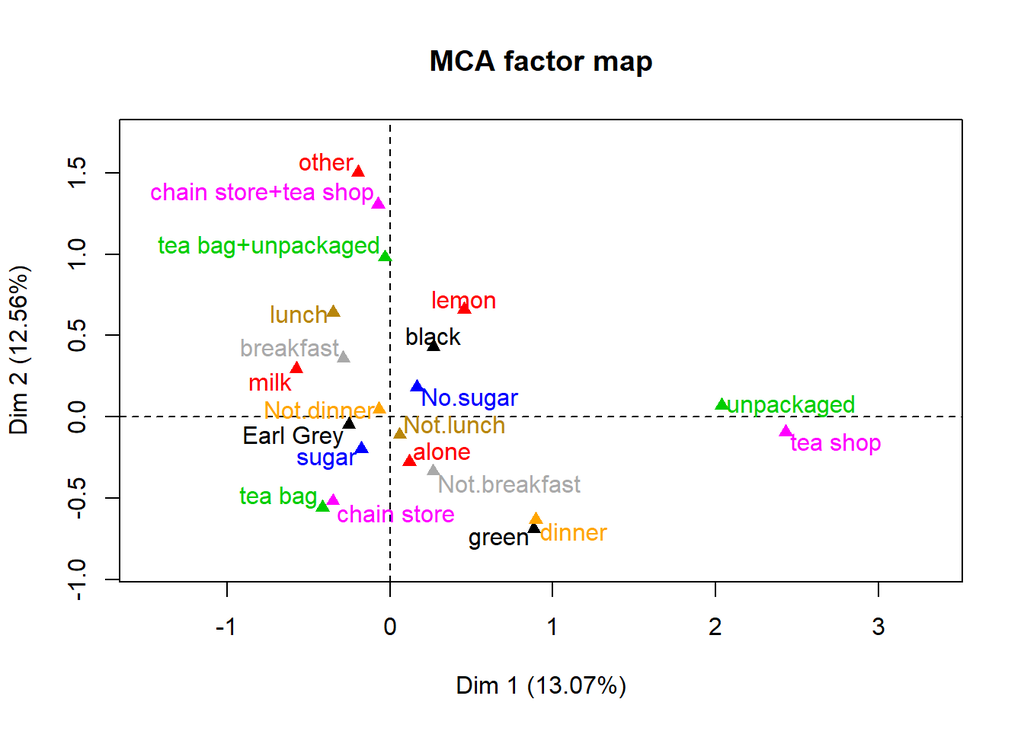

```r
# visualize MCA
plot(mca, invisible=c("ind"), habillage = "quali", graph.type = "classic")
```

We can plot not only variables, but also individuals. While the first plot shows that there is some over lap in habits between the drinkers of different kinds of tea, the second plot reveals that the sample is separated into three rather distinct group when it comes to where tea is bought.

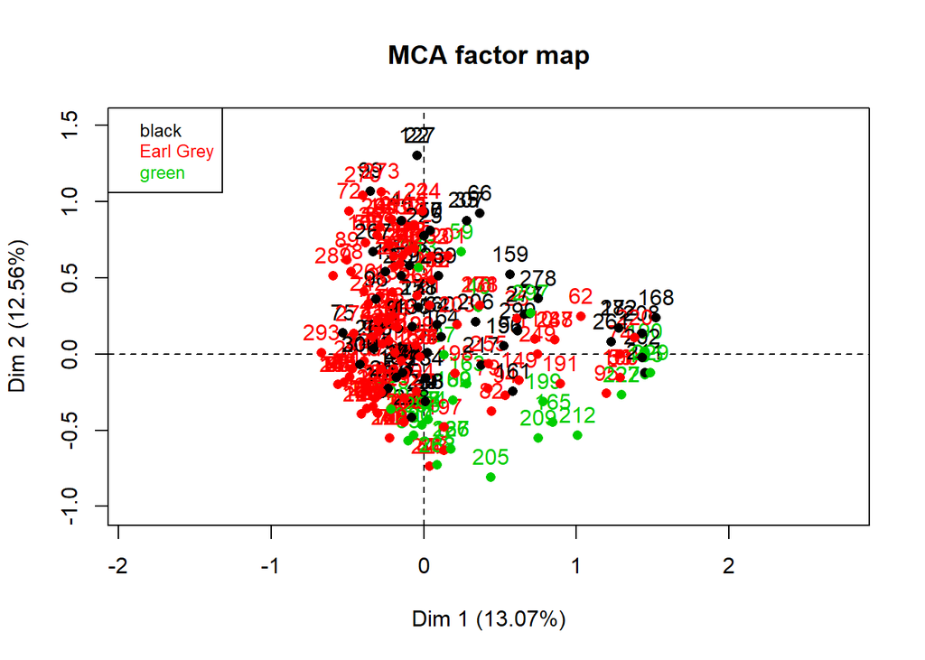

```r
plot(mca, invisible=c("var"), habillage = "Tea", graph.type = "classic")
```

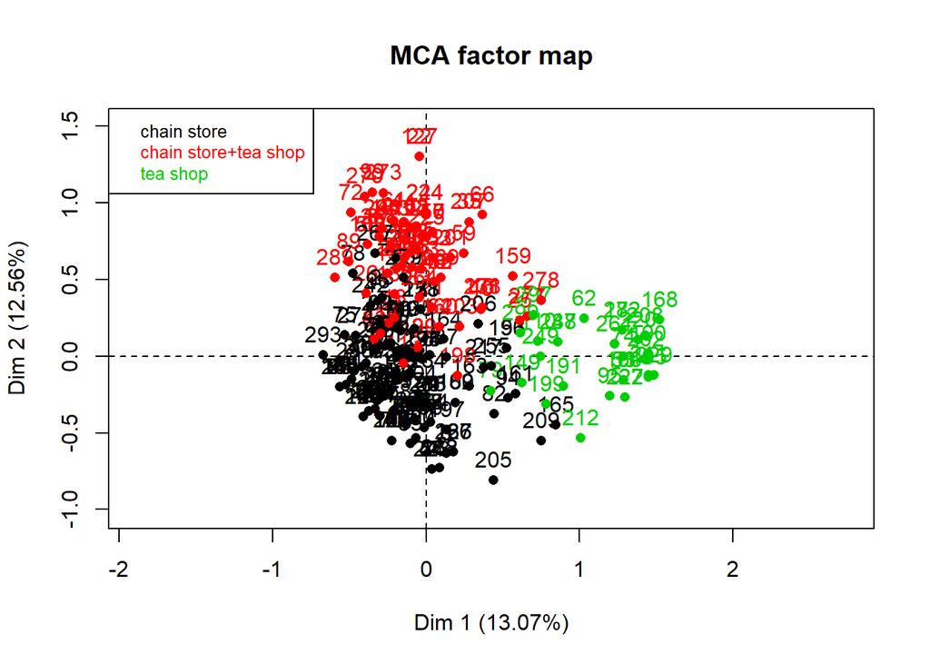

```r
plot(mca, invisible=c("var"), habillage = "where", graph.type = "classic")
```